# Succession - TV Show Report

Zuzanna Uljasz

May 2026

[figure not shown]

An image from *Succession*. (Warner Bros. Discovery Pressroom 2026)

# Overview

*Succession* is an American drama series about the wealthy *Roy* family, owners of the fictional global media company *Waystar RoyCo*. After the health of family patriarch *Logan Roy* begins to decline, his children — *Connor*, *Kendall*, *Roman*, and *Shiv* — compete for influence, control, and power within the company (Wikipedia 2026).

# Viewership Statistics

The table below shows the number of episodes and the average viewership of *Succession* by season (Wikipedia 2026).

```r
viewership <- data.frame(
  Season = c(1, 2, 3, 4),
  Episodes = c(10, 10, 9, 10),
  Release_Date = c("June 3, 2018", "August 11, 2019", "October 17, 2021", "March 26, 2023"),
  Average_Viewership_Mln = c(0.603, 0.597, 0.553, 0.705),
  Rotten_Tomatoes_Score = c(89, 97, 97, 97),
  Metacritic_Score = c(70, 89, 92, 92)
)

knitr::kable(
  viewership,
  caption = "Viewership and ratings statistics for *Succession*",
  col.names = c(
    "Season",
    "Episodes",
    "Release date",
    "Average viewership (mln)",
    "Rotten Tomatoes score",
    "Metacritic score"
  ),
  align = "c"
)
```

Viewership and ratings statistics for *Succession*

| Season | Episodes | Release date | Average viewership (mln) | Rotten Tomatoes score | Metacritic score |
| --- | --- | --- | --- | --- | --- |
| 1 | 10 | June 3, 2018 | 0.603 | 89 | 70 |
| 2 | 10 | August 11, 2019 | 0.597 | 97 | 89 |
| 3 | 9 | October 17, 2021 | 0.553 | 97 | 92 |
| 4 | 10 | March 26, 2023 | 0.705 | 97 | 92 |

```r
mean_viewership <- mean(viewership$Average_Viewership_Mln)
max_viewership <- max(viewership$Average_Viewership_Mln)
min_viewership <- min(viewership$Average_Viewership_Mln)

mean_rotten <- mean(viewership$Rotten_Tomatoes_Score)
mean_metacritic <- mean(viewership$Metacritic_Score)
```

The average viewership of *Succession* was **0.615** million viewers. The average *Rotten Tomatoes* score was **95**. The average *Metacritic* score was **85.8**. The highest average viewership was **0.705** million viewers, while the lowest was **0.553** million viewers.

## Viewership Over Time

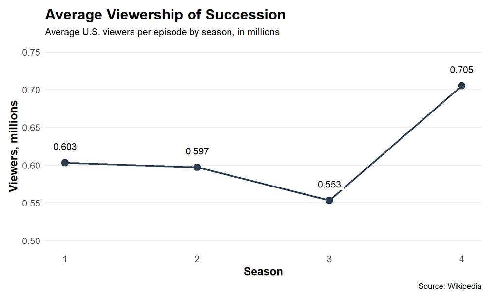

## Episode-to-episode viewership

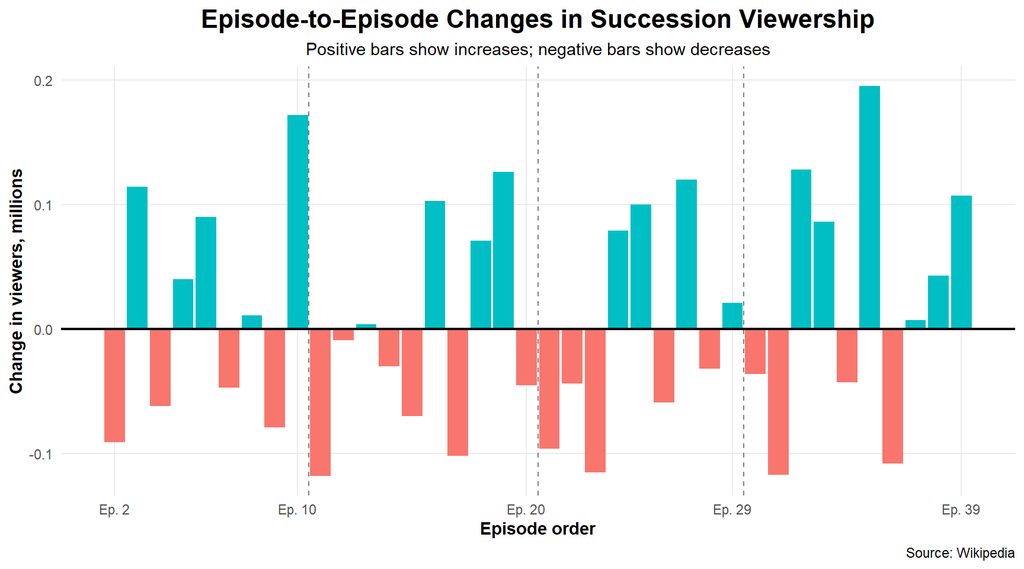

```r
library(ggplot2)

episode_viewership <- data.frame(
  Overall = 1:39,
  Season = c(rep(1, 10), rep(2, 10), rep(3, 9), rep(4, 10)),
  Episode = c(1:10, 1:10, 1:9, 1:10),
  Viewers_Mln = c(
    0.582, 0.491, 0.605, 0.543, 0.583, 0.673, 0.626, 0.637, 0.558, 0.730,
    0.612, 0.603, 0.607, 0.577, 0.507, 0.610, 0.508, 0.579, 0.705, 0.660,
    0.564, 0.520, 0.405, 0.484, 0.584, 0.525, 0.645, 0.613, 0.634,
    0.598, 0.481, 0.609, 0.695, 0.652, 0.847, 0.739, 0.746, 0.789, 0.896
  )
)

episode_viewership$Change_Mln <- c(NA, diff(episode_viewership$Viewers_Mln))
```

```r
first_episode <- episode_viewership$Viewers_Mln[1]
final_episode <- episode_viewership$Viewers_Mln[39]
overall_change <- final_episode - first_episode

lowest_viewership <- min(episode_viewership$Viewers_Mln)
lowest_episode <- episode_viewership$Overall[which.min(episode_viewership$Viewers_Mln)]

highest_viewership <- max(episode_viewership$Viewers_Mln)
highest_episode <- episode_viewership$Overall[which.max(episode_viewership$Viewers_Mln)]

largest_increase <- max(episode_viewership$Change_Mln, na.rm = TRUE)
largest_increase_episode <- episode_viewership$Overall[which.max(episode_viewership$Change_Mln)]

largest_decrease <- min(episode_viewership$Change_Mln, na.rm = TRUE)
largest_decrease_episode <- episode_viewership$Overall[which.min(episode_viewership$Change_Mln)]
```

The viewership of *Succession* increased overall from **0.582** million viewers in the first episode to **0.896** million viewers in the final episode. This was an increase of **0.314** million viewers.

The lowest viewership was recorded in episode **23**, with **0.405** million viewers, while the highest viewership was recorded in episode **39**, with **0.896** million viewers.

The largest episode-to-episode increase happened before episode **35**, when viewership rose by **0.195** million viewers. The largest episode-to-episode decrease happened before episode **11**, when viewership changed by **-0.118** million viewers.

# AI Usage

AI was used for minor text formatting and visualization, including improving the appearance of plots, hiding code chunks in the rendered report, and better rewording of the text content. AI was also used to help speed up the process of preparing the viewership data table.

# Bibliography

Warner Bros. Discovery Pressroom. 2026. “Succession.” https://press.wbd.com/na/property/succession.

Wikipedia. 2026. “Succession (TV Series).” https://en.wikipedia.org/wiki/Succession_(TV_series).